# Final Project Stat Learning

Zeke Hooper, Nina Farhat, Dean Smith

2024-12-08

The research question our group will be tackling is differentiating between Onion Articles (trolling news stories) and Real Articles from verified sources. We will explore our dataset with through looking at our labels along with words that are most common among both classes. We will use PCA as an unsupervised learning approach to our dataset along with a randoom forest model for a supervised approach and finally we will implement a neural network which we have not seen in class.

```r
library(tidyverse)
library(caret)
library(tidytext)
library(themis)
Onion <- read_csv("Onion Or Not.csv")
```

Class Imbalance

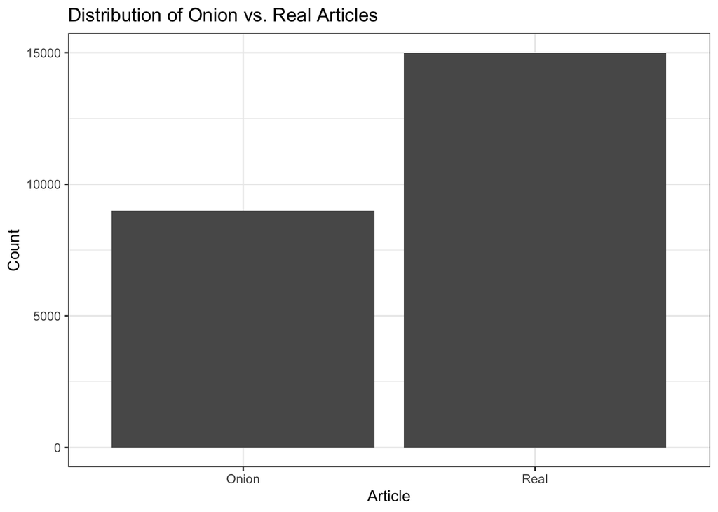

```r
Onion |>
  mutate(label = case_when(label == 1 ~ "Onion",
                           label == 0 ~ "Real")) |>
  ggplot() +
  geom_bar(aes(x = label)) +
  labs(x = "Article",
       y = "Count",
       title = "Distribution of Onion vs. Real Articles") +
  theme_bw()
```

This bar graph demonstrates the class imbalance in the dataset. There are 9000 Onion articles compared to 15000 real articles. This means that 37.5% of the dataset consists of Onion articles and 62.5% of the dataset consists of real articles. Onion is the minority class.

Cleaning the Data

```r
tokens <- Onion%>%
mutate(token_id = row_number()) %>%
unnest_tokens(input = "text",
                output = "Word",
                token = "words")%>%
  filter(!(Word %in% stop_words$word))

#See the most used Words

tokens%>%
  count(Word)%>%
  arrange(-n)
```

```
## # A tibble: 25,426 × 2
##    Word       n
##    <chr>  <int>
##  1 woman    943
##  2 police   870
##  3 life     726
##  4 news     706
##  5 trump    605
##  6 people   589
##  7 school   533
##  8 sex      529
##  9 day      389
## 10 time     384
## # ℹ 25,416 more rows
```

```r
tokens |>
  group_by(label, token_id) |>
  summarize(words_in_title = n()) |>
  group_by(label) |>
  summarize(mean_words_in_title = mean(words_in_title),
            sd_words_in_title = sd(words_in_title))
```

```
## # A tibble: 2 × 3
##   label mean_words_in_title sd_words_in_title
##   <dbl>               <dbl>             <dbl>
## 1     0                7.46              2.24
## 2     1                7.91              3.16
```

Each class has on average the same amount of words in each title.

```r
# Load necessary libraries
library(tm)
```

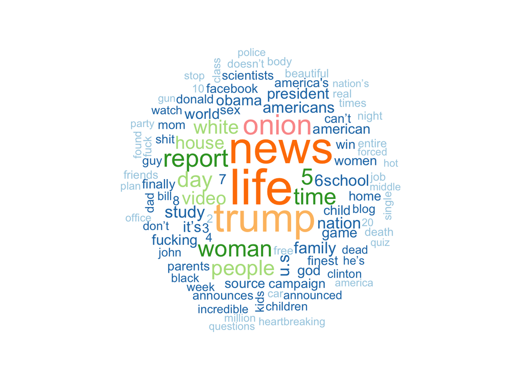

```r
library(wordcloud)
library(RColorBrewer)

data_with_freq <- tokens %>%
  group_by(Word, label) %>%
  summarise(freq = n(), .groups = "drop")

# Map colors to the words based on their label
data_with_freq_onion <- data_with_freq %>%
  filter(label == 1)

data_with_freq_not_onion <- data_with_freq %>%
  filter(label == 0)

# Generate the word cloud
wordcloud(
  words = data_with_freq_onion$Word,
  freq = data_with_freq_onion$freq,
  min.freq = 1,
  max.words = 100,
  random.order = FALSE,
  colors = brewer.pal(8, "Paired")
)
```

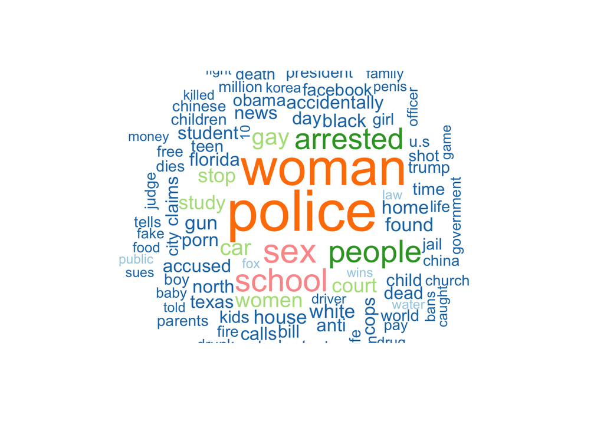

```r
wordcloud(
  words = data_with_freq_not_onion$Word,
  freq = data_with_freq_not_onion$freq,
  min.freq = 1,
  max.words = 100,
  random.order = FALSE,
  colors = brewer.pal(8, "Paired")
)
```

The word clouds increase in warmth of the color as well as the size of the word based on the frequency that word appears in each of the given article options. The first word cloud is a representation of the words that showed up most in the Onion articles, unsurprising the word “onion” appears a lot. Similar with the words “life” and “news”. Whereas when looking at articles that seem like they could be onion articles but are in fact not. We see that words like “police” and “woman” appear a lot in the headlines.

```r
# Building unique identifiers
tokens <- tokens %>%
  mutate(unique_id = paste(token_id, label, sep = "_"))

#pivot wider
dfm1 <- tokens %>%
  pivot_wider(
    id_cols = c("unique_id", "label"),
    names_from = "Word",
    values_from = "Word",
    values_fn = list(Word = length),
    values_fill = list(Word = 0),
    names_repair = "unique"
  )
article_word_counts <- dfm1%>%
  select_if(is.numeric)%>%
  colSums()

good_words <- names(article_word_counts[which(article_word_counts > 20)])


dfm2 <- dfm1 %>%
  select(all_of(good_words))

rename(dfm2, label = label...2)
```

```
## # A tibble: 23,992 × 1,825
##    label entire facebook staff privacy muslim woman denied  fear  move announced
##    <dbl>  <int>    <int> <int>   <int>  <int> <int>  <int> <int> <int>     <int>
##  1     1      1        1     1       1      0     0      0     0     0         0
##  2     0      0        0     0       0      1     1      1     1     0         0
##  3     1      0        0     0       0      0     0      0     0     1         1
##  4     1      0        0     0       0      0     0      0     0     0         0
##  5     1      0        0     0       0      0     0      0     0     0         0
##  6     1      0        0     0       0      0     0      0     0     0         0
##  7     0      0        0     0       0      0     0      0     0     0         0
##  8     0      0        0     0       0      0     0      0     0     0         0
##  9     1      0        0     0       0      0     0      0     0     0         0
## 10     1      0        0     0       0      0     0      0     0     0         0
## # ℹ 23,982 more rows
## # ℹ 1,814 more variables: `they’re` <int>, ahead <int>, `it’s` <int>,
## #   watch <int>, jeff <int>, bezos <int>, realizes <int>, `9` <int>,
## #   money <int>, lost <int>, divorce <int>, single <int>, women <int>,
## #   online <int>, dating <int>, offers <int>, finding <int>, term <int>,
## #   love <int>, kim <int>, jong <int>, nuclear <int>, threats <int>,
## #   real <int>, dad <int>, pot <int>, eats <int>, `4` <int>, cat <int>, …
```

```r
dfm2_subset <- dfm2%>%
  select(-label...2)

onion.pca <- prcomp(dfm2_subset, scale = TRUE)
```

Due to the size of the data set, and after trying to brute force a random forest on 23992 x 25428 we came to the conclusion that we had to reduce the computational load on the model. We then use PCA or Principle Component Analysis to reduce the dimensionality of the data set. This method reduces the dimensions of the data by standardizing all variables with a mean of 0 and a variance of 1. This essentially means that it creates unique values for each row based on a culmination of all the explanatory variables that are given to the function. This output a single value which is the value of PC loadings, but it does this multiple times equal to the number of variables to eventually describe all the variation in the data set. However, you are able to discern most of the variation from relatively small numbers of loadings in the analysis. By looking at the different loadings values you can see which words were relatively valuable in understandings differences observations of titles. This method was critically to the rest of the analysis since the computational load was very high before. Importantly, this lowers the overall interpretability of our future findings because each value or explanatory variable is a culmination of all the variables with different weights described in one or in our case five different variables.

```r
onion.rf <- dfm2 %>%
  mutate(PC1 = onion.pca$x[,1],
         PC2 = onion.pca$x[,2],
         PC3 = onion.pca$x[,3],
         PC4 = onion.pca$x[,4],
         PC5 = onion.pca$x[,5])%>%
  select(label...2, PC1, PC2, PC3, PC4, PC5)
```

We tried adding in more PC loading to improve the accuracy of the model from gleaning more information from the additional loading being added the model. Instead it improved the accuracy of the model marginally by ~1 percentage point. This also increase the run time of the model by significant run time. We then reduced the number of loadings in our analysis to 3 instead of 5 and found that that lowered out results by ~5 percentage points of accuracy. This meant that we stuck with 5 of our loadings to help of classify our different articles as being from or not from the onion.

```r
model_PC <- train(as.character(label...2) ~ PC1 + PC2 + PC3 + PC4 + PC5,
                    data = onion.rf,
                    method = "ranger",
                    importance = "impurity",
                  trControl = trainControl(
  method = "cv",
  number = 5,
  sampling = "smote"  # Use SMOTE for balancing
))


varImp(model_PC)
```

```
## ranger variable importance
##
##     Overall
## PC3  100.00
## PC1   68.61
## PC4   56.32
## PC5    2.54
## PC2    0.00
```

```r
model_PC$results
```

```
##   mtry min.node.size  splitrule  Accuracy     Kappa  AccuracySD     KappaSD
## 1    2             1       gini 0.7149050 0.4057893 0.003793901 0.007951158
## 2    2             1 extratrees 0.7202819 0.4190932 0.003197092 0.004731759
## 3    3             1       gini 0.7125710 0.4014575 0.003181331 0.005065475
## 4    3             1 extratrees 0.7184896 0.4148661 0.004341379 0.006312038
## 5    5             1       gini 0.7124876 0.4007229 0.004056168 0.008471131
## 6    5             1 extratrees 0.7158639 0.4087804 0.004330248 0.005767086
```

```r
confusionMatrix(model_PC)
```

```
## Cross-Validated (5 fold) Confusion Matrix
##
## (entries are percentual average cell counts across resamples)
##
##           Reference
## Prediction    0    1
##          0 46.0 11.4
##          1 16.6 26.1
##
##  Accuracy (average) : 0.7203
```

This model is using a random forest approach. How that works is it takes into a lot of different inputs, which are the different explanatory variables for our outcome being which platform our article came from based on the words that appear in the headline. The decisions of what to split are based on the in sample amount of different observation, this is know as the in bag sample. Where you take a random assortment of the different observations with replacement meaning the same observations can appear multiple time. From there you train your model looking for different splits on the PC loadings at each decisions to classify which of the observations look the same and which observations look different. Once we have done this method we then go over and test the model on out of bag observation which were not used to train the model and see how well our model does. That is how we find the accuracy of the model and how good it is at identifying which observations came from different headlines. We have also controlled for the imbalance in our data set by adding a method that creates synthetic observations that match what other characterize the minority class.

Confusion Matrix: This is a representation of the accuracy of the model. Unlike other model we are looking for raw accuracy because our main goal is to increase our classification rate. In other model having false negatives (incorrectly thinking something was true when in fact it was false) or false positives (incorrectly thinking was false when in fact it was true) can be reflective of the model accuracy since those difference can determine how good of a classification model you have. For example if you false think someone does not have cancer when they in fact do have cancer can carry more weight than telling someone the inverse. However, in our case we are looking for how good the model is at predicting 0 and it being in fact 0 (not an onion article) and at predicting 1 when in fact it is 1 (an onion article).

VarImp: Is the representation of which loadings are contributing the most to the classification in the model

Results: These are the different tries of how many different options were shown for node splits at every branch and which was the most effective of the methods.

```r
library(xgboost)
```

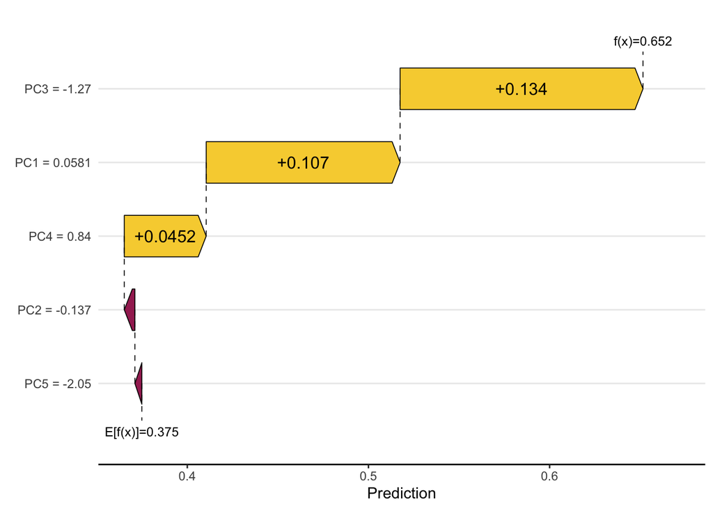

```r
onion.boost <- onion.rf%>%
  select(-label...2)


boost_data <- xgb.DMatrix(data.matrix(onion.boost),
                          label = as.character(onion.rf$label...2))

boost_model <- xgb.train(data = boost_data,
                         nrounds = 65,
                         params =  list(learning_rate = 0.1,
                                        objective = "reg:squarederror"))


#Visualize SHAP/Shapley Values
library(shapviz)
shap_values <- shapviz(boost_model,
                       X_pred = data.matrix(onion.boost),
                       X = onion.boost)

#Graph these values
#Waterfall plot

sv_waterfall(shap_values, row_id = 1)
```

```r
onion.rf$label...2[1]
```

```
## [1] 1
```

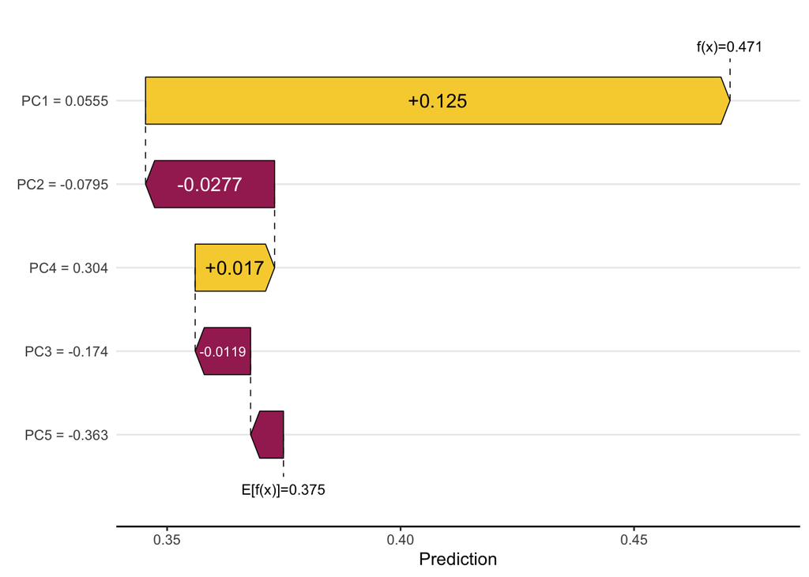

```r
#Hit

sv_waterfall(shap_values, row_id = 1111)
```

```r
onion.rf$label...2[1111]
```

```
## [1] 0
```

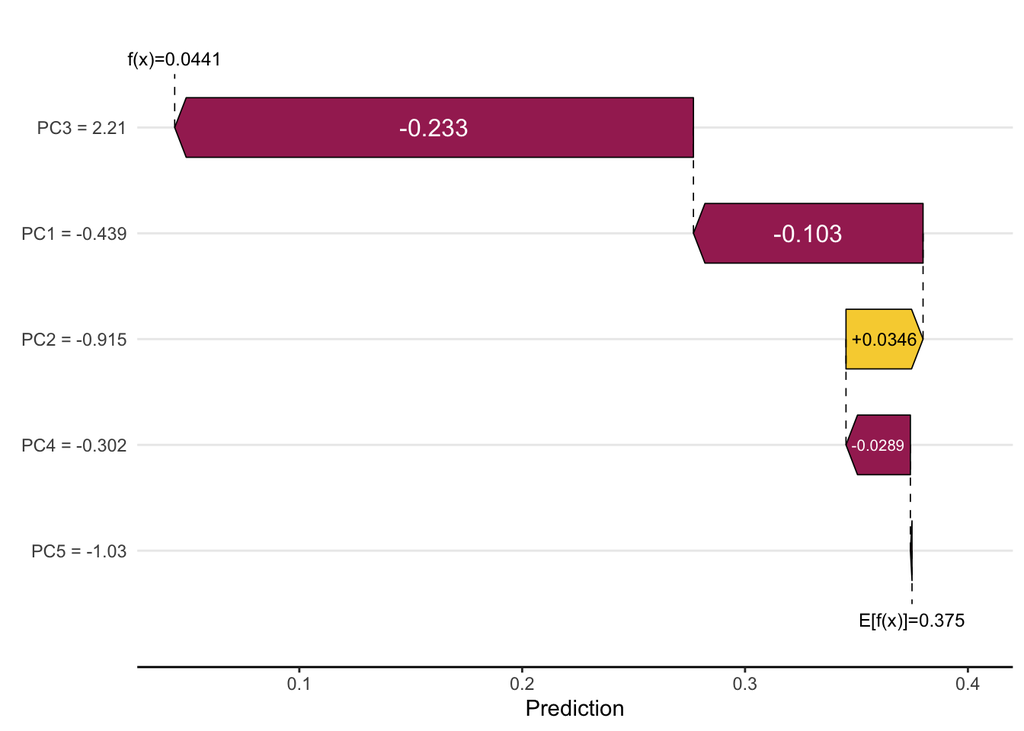

```r
#Miss


sv_waterfall(shap_values, row_id = 1113)
```

```r
onion.rf$label...2[1113]
```

```
## [1] 0
```

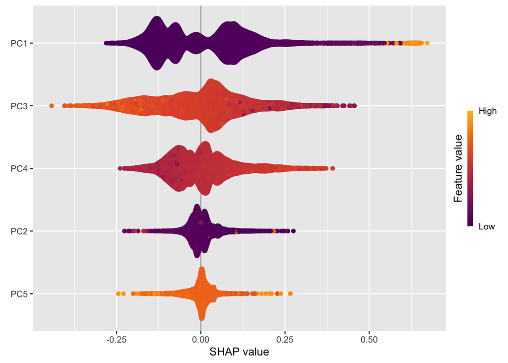

```r
#Hit

sv_importance(shap_values, kind = "beeswarm")
```

We used gradient boosting as another method to classify unlabeled article titles and to determine the usefulness of each predictor variable. First, we removed the “label…2” identifier column from the DFM used for the random forest model. The DFM consisted of only the first five PCs from our PCA so that the model ran within a reasonable time frame. Then, we converted the DFM into an XGBoost DMatrix format so that the XGBoost function could be efficiently trained. Correct formatting is required so that the function works properly. Finally, we added the identifier column back as “label” and set it as the target variable so that the XGBoost model knows what to predict. We set nrounds equal to 65 so that the model would fit 65 trees. Basically, the model combines many “weak learners” which in this case are individual decision trees that start out by performing slightly better than random guessing. The XGBoost model learns from each previous decision tree and slightly improves the next one. We figured 65 was a reasonable number based on the size of our data. We also set the learning rate equal to 0.1 so that the model would run within a reasonable amount of time while still maintaining reasonable accuracy. 0.1 means that the model improves the next decision tree by 10% based on the previous decision tree. The objective is set to “reg:squarederror” so that the model’s goal is to reduced the squared error between the prediction and target as much as possible. Essentially, the final boosting tree is the sum of all 65 trees.

Finally, the model that our group will be implementing with our data that has not been seen class is a Neural Network. A Neural Network is modeled similarly to human brains and how we learn. Formally, the model is broken into neurons and weights where the starting layer of neurons is the input layer for a given observation. The input layer is connected to the hidden layers through weighted neuron connections which essentially tell us how important a given feature is to the next neuron in the connection. Similar to how our brains work, neurons have activiation functions that determine whether they are “firing” or not. Common activation functions are the sigmoid function and the ReLU function. The mathmatical formula for how a given neuron fires is the sum of the weight*input pairs along with adding a bias term which is then input to an activation function to see whether or not the neuron fires. The output layer is the final layer of the neural network with size 1 (in our case since we are doing a classification task) where the result tells us how to classify the given example.

To start, the weights are randomly initialized as we have no idea what the relationships are since this is the models job to figure out. We then give our model a training set of data to adjust its weights. There are many hyperparameters involved in a neural network but many have to do with the training process. One of the hyperparameters is batch size which specifies how many examples the model should look at before adjusting its weights accordingly. Secondly, the learning rate, labeled with the alpha symbol, represents how much the weights should be adjusted for each update. In regards to these hyperparameters, too small of a batch size will lead to overfitting and too large of a batch size will underfit our data and over generalize. For learning rate, the same principle applies so we want to find a balance between the two. Another hyperparameter present during the training process is epochs which is the number of times the model will see the data. There is research that suggests training a model on the same data (up to a certain extent) can increase the model’s performance.

To train our model, we first need to do a test/train split of our data.

```r
train_size <- floor(0.70 * nrow(onion.rf))

set.seed(69)

train_ind <- sample(seq_len(nrow(onion.rf)), size = train_size)

train <- onion.rf[train_ind, ]
test <- onion.rf[-train_ind, ]
```

Now that we have split our data into a training and testing dataset with 70% of our data allocated to training, now we can train our model. For our model implementation, we will use caret’s nnet method in the train function. This function will take care of the hyperparameter tuning except it has a fixed number of hidden layers (1). For most cases, there really only needs to be 1 hidden layer so we most likely would not need to add more. Additionally, if we had no hidden layers, the neural network would just function as a linear regression classifier which we do not want. In this way, only Having 1 hidden layer from the caret package will be sufficient for our model development. The caret package also uses the entire dataset as a batch making this hyperparameter out of our control as well.

```r
train$label...2 <- as.factor(train$label...2)

model <- train(
  label...2 ~ .,
  data = train,
  method = "nnet",
  trace = FALSE
)

print(model)
```

```
## Neural Network
##
## 16794 samples
##     5 predictor
##     2 classes: '0', '1'
##
## No pre-processing
## Resampling: Bootstrapped (25 reps)
## Summary of sample sizes: 16794, 16794, 16794, 16794, 16794, 16794, ...
## Resampling results across tuning parameters:
##
##   size  decay  Accuracy   Kappa
##   1     0e+00  0.7212291  0.3924291
##   1     1e-04  0.7212292  0.3924377
##   1     1e-01  0.7213196  0.3927130
##   3     0e+00  0.7229235  0.3936798
##   3     1e-04  0.7244235  0.3952730
##   3     1e-01  0.7254127  0.3966816
##   5     0e+00  0.7258831  0.3981992
##   5     1e-04  0.7249385  0.3965228
##   5     1e-01  0.7254506  0.3976968
##
## Accuracy was used to select the optimal model using the largest value.
## The final values used for the model were size = 5 and decay = 0.
```

The model shows the different training iterations based on size or hidden layer size, decay which handles overfitting, and decides the model based on accuracy.

```r
predictions <- predict(model, test)

labels <- as.factor(test$label...2)

accuracy <- confusionMatrix(predictions, labels)

accuracy
```

```
## Confusion Matrix and Statistics
##
##           Reference
## Prediction    0    1
##          0 3721 1194
##          1  791 1492
##
##                Accuracy : 0.7242
##                  95% CI : (0.7137, 0.7345)
##     No Information Rate : 0.6268
##     P-Value [Acc > NIR] : < 2.2e-16
##
##                   Kappa : 0.3921
##
##  Mcnemar's Test P-Value : < 2.2e-16
##
##             Sensitivity : 0.8247
##             Specificity : 0.5555
##          Pos Pred Value : 0.7571
##          Neg Pred Value : 0.6535
##              Prevalence : 0.6268
##          Detection Rate : 0.5169
##    Detection Prevalence : 0.6828
##       Balanced Accuracy : 0.6901
##
##        'Positive' Class : 0
##
```

With an accuracy of about 72%, our model performs similar to the random forest model we created with nothing notable about the confusion matrix.

Finally, lets see what our neural netwrok looks like:

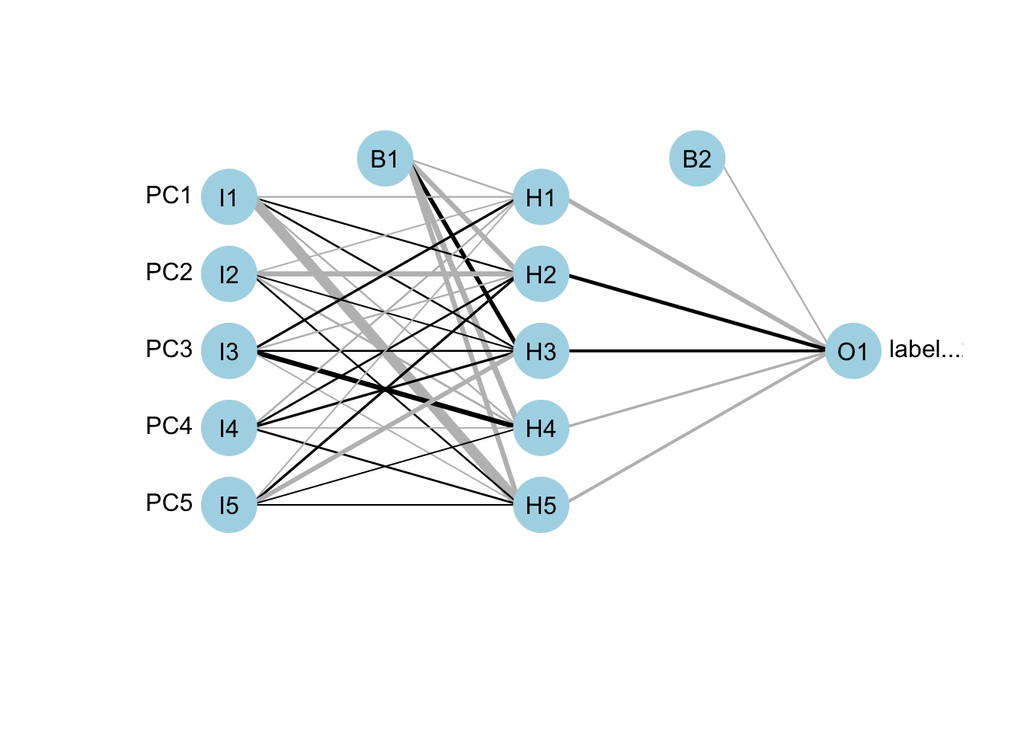

```r
library(NeuralNetTools)

plotnet(model)
```

We can see in the plot above the inputs on the left followed by the hidden layer and finally the output neuron. We can also see the biases added to their respective layers along with the values for the weights being denoted with thicket lines.

To answer our initial research question, we feel that both supervised learning approaches we used did a good job at classifying the different articles. Given that our models are not using any contextual word embeddings or anything that would give them knowlege about the articles, our models exceed the baseline accuracy of 62.5%, just guessing all real articles, significantly. Some things that may help improve our model would be better or higher dimensional word embeddings along with more data. While our approaches are not "state of the art" by no means, we would reccomend for social media platforms to use models similar to the ones we have used in order to filter "trolling" accounts and combat fake news given that we have had success with our approach.